# COVID-19 proteome response across two sample matrices

Olink reanalysis: differential expression, cross-matrix concordance, severity structure, and data quality

Author

Elisa Marquez

Published

September 15, 2026

# Summary

At a pre-specified FDR of 5% (no effect-size filter), 210 of 436 proteins differ between COVID-positive and negative samples in the plasma subcohort (170 up, 40 down in COVID) and 209 in the serum subcohort (201 up, 8 down). 145 proteins are significant in both matrices, and **100% of them move in the same direction**. Across all 436 shared assays, fold changes correlate at Spearman ρ = 0.80.

The two matrices tell one biological story: the acute COVID response (interferon signaling, cytokines, endothelial activation) dominates in both, with serum showing systematically larger effect sizes (regression slope serum ~ plasma = 1.58).

# Data and methods

**Data.** Two Olink sample matrices from the same study: a longitudinal plasma subcohort (307 samples) and a serum subcohort (63 samples), each measuring 436 proteins across five panels (CM, CVD2, CVD3, Inflammation, Immune Response). Negative (control) samples in the plasma subcohort are dialysis patients – chronically inflamed relative to healthy donors – which compresses observed effect sizes.

**Preprocessing.** Protein x sample matrices were built per subcohort from the harmonized long table. Pre-specified missingness rule (identical for DE, PCA, and heatmaps): proteins with >20% missing values are dropped (none were, in either matrix); remaining gaps are median-imputed per protein. Values are Olink NPX (already log2 scale).

**Differential expression.** Linear models per protein (limma) contrasting COVID-positive vs negative. The plasma design accounts for repeated individuals via `duplicateCorrelation` (estimated intra-individual correlation r = 0.617). P-values are BH-adjusted across 436 tests.

**Dimensionality reduction.** Sample-level PCA on per-protein z-scores (proteins standardized across samples, so PCs reflect correlation structure rather than raw NPX abundance).

**Data quality.** Missingness is enumerated per assay and per sample (encoded as absent source rows); outliers are screened as Euclidean distance to the own-group centroid in PC1-PC5 (robust z, one-sided, threshold 3); plate x group balance is tabulated. QC flags are informational – no samples are excluded (no pre-specified exclusion rule).

# Results: differential expression

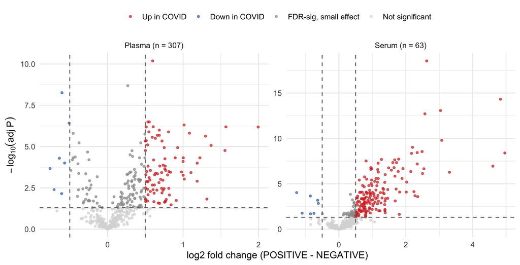

Volcano plots at the pre-specified display thresholds (|logFC| > 0.5, FDR < 0.05). Dashed lines: display thresholds.

With the effect-size filter applied, 97 plasma and 173 serum proteins clear both display thresholds. Down-regulation is rare and weak – consistent with an acute inflammatory state sitting on top of a chronically inflamed control group.

Plasma: 10 strongest up-regulated proteins by FDR

| Assay | UniProt | Panel | logFC | adj.P |
| --- | --- | --- | --- | --- |
| LAMP3 | Q9UQV4 | IR | 0.60 | 0e+00 |
| Gal-9 | O00182 | CVD2 | 0.27 | 0e+00 |
| HO-1 | P09601 | CVD2 | 0.53 | 3e-07 |
| TNF-R2 | P20333 | CVD3 | 0.55 | 3e-07 |
| IL-1ra | P18510 | CVD2 | 1.01 | 5e-07 |
| BLM hydrolase | Q13867 | CVD3 | 0.61 | 6e-07 |
| MCP-3 | P80098 | In | 1.57 | 6e-07 |
| CTSL1 | P07711 | CVD2 | 0.51 | 7e-07 |
| DDX58 | O95786 | IR | 1.99 | 7e-07 |
| LILRB4 | Q8NHJ6 | IR | 0.69 | 1e-06 |

Serum: 10 strongest up-regulated proteins by FDR

| Assay | UniProt | Panel | logFC | adj.P |
| --- | --- | --- | --- | --- |
| EIF4G1 | Q04637 | IR | 2.62 | 0 |
| DDX58 | O95786 | IR | 4.83 | 0 |
| TRIM21 | P19474 | IR | 3.04 | 0 |
| CASP-8 | Q14790 | In | 2.57 | 0 |
| TRIM5 | Q9C035 | IR | 3.07 | 0 |
| IRF9 | Q00978 | IR | 2.20 | 0 |
| ZBTB16 | Q05516 | IR | 2.49 | 0 |
| ITGB1BP2 | Q9UKP3 | CVD2 | 2.34 | 0 |
| IL6 | P05231 | In | 4.96 | 0 |
| ST2 | Q01638 | CVD3 | 2.17 | 0 |

# Results: cross-matrix concordance

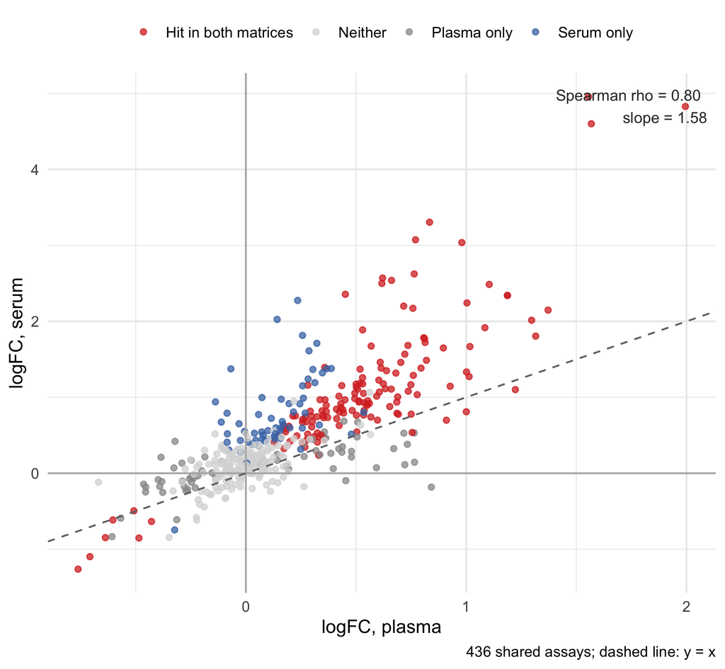

Fold-change concordance across matrices for all shared assays. Dashed: identity line.

Of 210 plasma and 209 serum hits, 145 are significant in both matrices – and every shared hit points the same way (100% direction concordance). Serum fold changes run systematically steeper (slope 1.58), consistent with its controls sitting closer to baseline.

# Results: PCA and severity structure

Sample-level PCA (per-protein z-scores; PC1 captures 19.1% and PC2 8.9% of variance in plasma) separates COVID-positive from negative samples along PC1 — standardized separation of 1.05 SD (Cohen’s d) in plasma, and similarly in serum (25.6% on PC1).

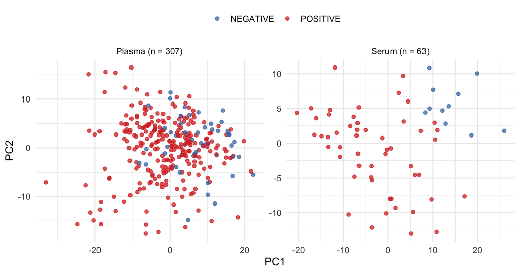

Sample PCA: PC1 vs PC2 colored by group (red = POSITIVE, blue = NEGATIVE). Axes are fixed by the full-subcohort artifact.

In plasma, PC1 does not merely separate disease from control — it **grades with severity**. Mean PC1 by category:

Mean PC1 by severity category, plasma subcohort

| Severity | n | mean_PC1 |
| --- | --- | --- |
| NEGATIVE | 51 | 7.0 |
| mild | 73 | 4.6 |
| moderate | 62 | -0.9 |
| severe | 74 | -2.3 |
| critical | 47 | -10.0 |

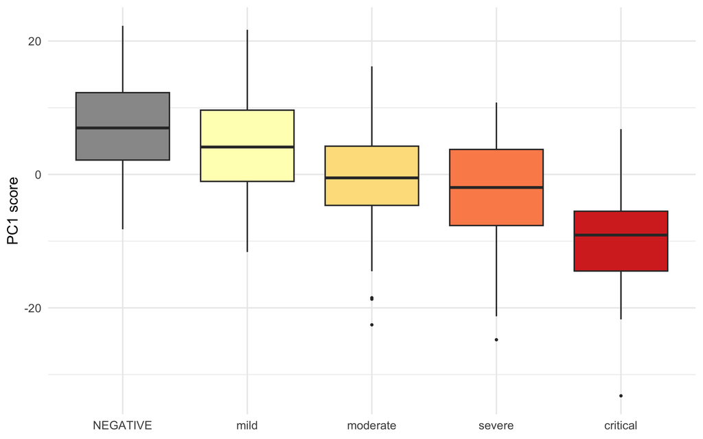

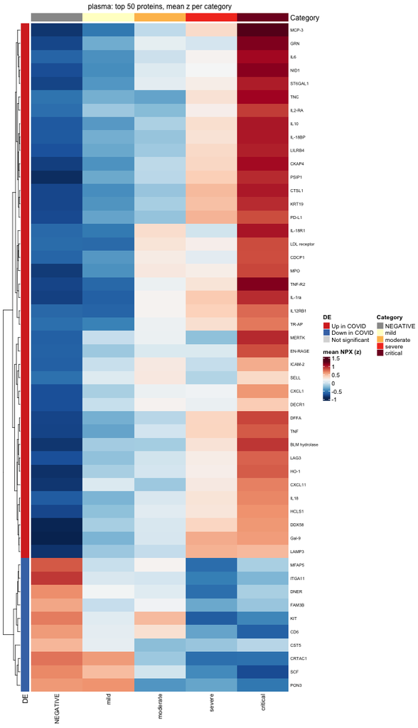

Plasma: severity categories

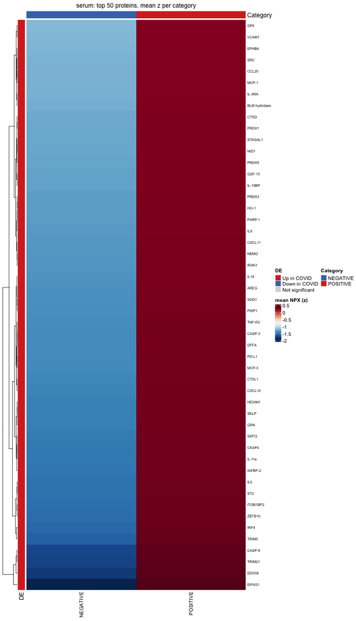

Serum: group categories

Top-50 DE proteins, mean per-protein z-score per category. Left bar: DE direction. Plasma categories are severity levels; serum falls back to Group (no severity annotations available).

The per-sample heatmap (307 columns for plasma, with Group/Severity column annotations) is best explored interactively in the app’s Heatmap tab.

# Data quality

QC summary per subcohort. All values computed live from qc.rds artifacts.

| Subcohort | Samples | Assays | Missing cells | % missing | Assays >20% | Samples >20% | Outliers | Plates |
| --- | --- | --- | --- | --- | --- | --- | --- | --- |
| Plasma | 307 | 436 | 275 | 0.21 | 0 | 0 | 6 | 5 |
| Serum | 63 | 436 | 97 | 0.35 | 0 | 0 | 0 | 1 |

**Missingness is trivially low overall** — 0.21% of plasma cells and 0.35% of serum cells — and **concentrated in three plasma samples with complete single-panel dropouts**:

Samples C10_6, C189_345, C224_361 each lost one entire panel (CVD2, CVD2, IR — 87 assays each; all other panels fully observed). Each sits just under the pre-specified 20% threshold (19.95% missing) and is retained under the fixed rule; together they account for 261 of the 275 missing plasma cells (95%). Affected values are median-imputed per the preprocessing rule. QC flags informational; no samples excluded (no pre-specified rule). A sensitivity re-run excluding these three samples is listed as future work.

**Outliers.** The within-group screen (Euclidean distance to own-group centroid in PC1-PC5, robust z (median/MAD), one-sided) flags 6 plasma samples (C65_11, C27_240, C24_211, C10_47, C99_299, C11_237; all POSITIVE) and none in serum. Flags are informational.

**Plates.** Plasma controls are spread across all 5 plates by design (~10-11 per plate), so plate cannot confound group:

Plasma: samples per plate x group. Controls distributed across plates by design.

| Plate | NEGATIVE | POSITIVE |
| --- | --- | --- |
| plate.1 | 10 | 54 |
| plate.2 | 10 | 64 |
| plate.3 | 10 | 65 |
| plate.4 | 11 | 68 |
| plate.5 | 10 | 5 |

Serum is a single plate, so batch QC is not applicable there. LOD flags not computable: LOD fields absent from the harmonized dataset.

# Limitations and future work

**Limitations.**

- **Control group.** Plasma negatives are dialysis patients – chronically inflamed relative to healthy donors – so observed effect sizes are conservative (compressed toward zero). Direction of change is robust; magnitudes are not comparable to healthy-baseline studies.
- **Serum power.** The serum subcohort has 11 negative samples (of 63 total), so serum-only findings carry wide uncertainty.
- **Unbridged matrices.** No Olink bridge normalization links the two subcohorts; every statistical test is within-matrix. Cross-matrix statements are qualitative (direction concordance, rank correlation) – not quantitative equivalence of effect sizes.
- **No LOD information.** LOD flags not computable: LOD fields absent from the harmonized dataset.

**Future work**, in priority order:

1. **Severity contrast DE** (severe vs mild among positives; bins of 74 vs 73): the PC1 dose-response and category heatmap strongly suggest severity effects will replicate at the DE level.
2. **Sensitivity re-run** excluding the three full-panel-dropout samples – a one-line change to the pipeline inputs, then diff against the current `de_results.rds`.
3. **LOD-aware QC** once limit-of-detection fields become available.

**Reproducibility.** Every number and figure in this report is computed at render time from the committed pipeline artifacts (`outputs/<subcohort>/{de_results,pca,heatmap,qc}.rds`); nothing is transcribed by hand. Pipelines live in `R/run_*.R` (harmonize → DE → PCA → heatmap → QC); the companion Shiny app serves the same artifacts, so report, app, and data cannot drift apart.